# Chapter-09.Rmd

Do a Bayesian analysis of hypocotyl length (hyp) in the attached data sheet.

1. Consider treatment effects (trt) species effects (species) and their interaction. What is the best model given these possible predictors?
2. Use “S. chmielewskii” as the reference. For each of the other species evaluate the hypothesis that their response to shade differs from S. chmielewskii.

# Load and Look at Data

```r
library("rethinking")
```

```r
library("ggplot2")
library("reshape2")

d = read.csv("/Users/gturco/Documents/2011_2016_PHD/code/Rclub-rethinking_Gina.Turco/Assignment_Chapter_09/TomatoR2CSHL.csv",header=TRUE)

### first look at the data does it look how we cant it to look
head(d)
```

```
##   shelf flat col row    acs trt days   date   hyp int1 int2 int3 int4
## 1     Z    1   B   1 LA2580   H   28 5/5/08 19.46 2.37 1.59 1.87 0.51
## 2     Z    1   C   1 LA1305   H   28 5/5/08 31.28 3.34 0.01 9.19 1.62
## 3     Z    1   D   1 LA1973   H   28 5/5/08 56.65 8.43 2.39 6.70 3.69
## 4     Z    1   E   1 LA2748   H   28 5/5/08 35.18 0.56 0.00 1.60 0.61
## 5     Z    1   F   1 LA2931   H   28 5/5/08 35.32 0.82 0.02 1.49 0.46
## 6     Z    1   G   1 LA1317   H   28 5/5/08 28.74 1.07 6.69 5.72 4.76
##   intleng totleng petleng leafleng leafwid leafnum ndvi      lat      lon
## 1    6.34   25.80   15.78    30.53   34.44       5  111  -9.5167 -78.0083
## 2   14.16   45.44   12.36    22.93   13.99       4  120 -13.3833 -75.3583
## 3   21.21   77.86   13.05    46.71   43.78       5  110 -16.2333 -71.7000
## 4    2.77   37.95    8.08    26.82   33.28       5  105 -20.4833 -69.9833
## 5    2.79   38.11    7.68    22.40   23.61       5  106 -20.9167 -69.0667
## 6   18.24   46.98   23.66    42.35   42.35       5  132 -13.4167 -73.8417
##    alt         species who
## 1  740    S. pennellii Dan
## 2 3360   S. peruvianum Dan
## 3 2585   S. peruvianum Dan
## 4 1020     S. chilense Dan
## 5 2460     S. chilense Dan
## 6 2000 S. chmielewskii Dan
```

```r
### how is it cat the data does it think it is numeric, flat for example is not a factor as trtment is.. also check if things where inported at lowercase or upercase. Also see if any missing data point
summary(d)
```

```
##  shelf        flat            col           row            acs
##  U:161   Min.   : 1.00   G      :133   Min.   :1.00   LA1954 : 40
##  V:174   1st Qu.: 9.00   H      :127   1st Qu.:2.00   LA2695 : 39
##  W:178   Median :17.00   F      :125   Median :3.00   LA1361 : 37
##  X:174   Mean   :17.89   C      :117   Mean   :2.56   LA2167 : 37
##  Y:125   3rd Qu.:28.00   D      :117   3rd Qu.:4.00   LA2773 : 37
##  Z:196   Max.   :36.00   E      :107   Max.   :4.00   LA1474 : 36
##                          (Other):282                  (Other):782
##  trt          days           date          hyp             int1
##  H:495   Min.   :28.00   5/5/08:716   Min.   : 6.17   Min.   : 0.00
##  L:513   1st Qu.:28.00   5/6/08:292   1st Qu.:26.81   1st Qu.: 1.74
##          Median :28.00                Median :32.02   Median : 3.59
##          Mean   :28.29                Mean   :33.36   Mean   : 4.71
##          3rd Qu.:29.00                3rd Qu.:38.56   3rd Qu.: 6.46
##          Max.   :29.00                Max.   :74.60   Max.   :39.01
##                                                       NA's   :1
##       int2             int3             int4           intleng
##  Min.   : 0.000   Min.   : 0.010   Min.   : 0.030   Min.   : 0.000
##  1st Qu.: 1.060   1st Qu.: 2.975   1st Qu.: 2.163   1st Qu.: 9.637
##  Median : 3.120   Median : 5.625   Median : 3.995   Median :17.255
##  Mean   : 4.287   Mean   : 6.794   Mean   : 5.102   Mean   :20.340
##  3rd Qu.: 6.320   3rd Qu.: 9.367   3rd Qu.: 7.018   3rd Qu.:28.145
##  Max.   :28.980   Max.   :27.760   Max.   :23.280   Max.   :92.420
##  NA's   :1        NA's   :4        NA's   :102
##     totleng          petleng         leafleng        leafwid
##  Min.   : 13.59   Min.   : 1.53   Min.   : 9.74   Min.   : 8.29
##  1st Qu.: 39.25   1st Qu.:11.20   1st Qu.:27.43   1st Qu.:29.48
##  Median : 50.98   Median :15.13   Median :34.59   Median :39.62
##  Mean   : 53.70   Mean   :15.92   Mean   :35.54   Mean   :39.29
##  3rd Qu.: 64.76   3rd Qu.:20.48   3rd Qu.:42.98   3rd Qu.:47.75
##  Max.   :129.43   Max.   :44.44   Max.   :95.19   Max.   :90.27
##                   NA's   :2       NA's   :1       NA's   :1
##     leafnum           ndvi          lat               lon
##  Min.   :3.000   Min.   :100   Min.   :-25.400   Min.   :-78.52
##  1st Qu.:5.000   1st Qu.:108   1st Qu.:-16.607   1st Qu.:-75.92
##  Median :5.000   Median :115   Median :-14.152   Median :-73.63
##  Mean   :5.063   Mean   :118   Mean   :-14.490   Mean   :-73.71
##  3rd Qu.:6.000   3rd Qu.:128   3rd Qu.:-12.450   3rd Qu.:-71.70
##  Max.   :8.000   Max.   :137   Max.   : -5.767   Max.   :-68.07
##  NA's   :1
##       alt                  species      who
##  Min.   :   0   S. chilense    :207   Dan :402
##  1st Qu.:1020   S. chmielewskii:226   Pepe:606
##  Median :2240   S. habrochaites:226
##  Mean   :2035   S. pennellii   :132
##  3rd Qu.:3110   S. peruvianum  :217
##  Max.   :3540
##
```

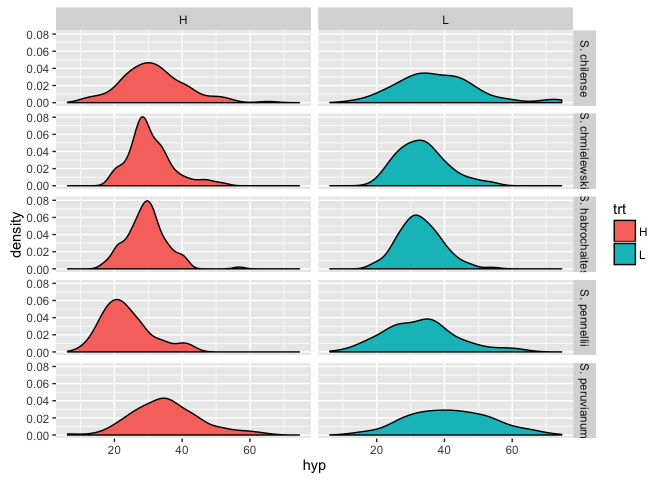

```r
ggplot(data=d,aes(x=hyp,fill=trt)) + geom_density() + facet_grid(species~trt)
```

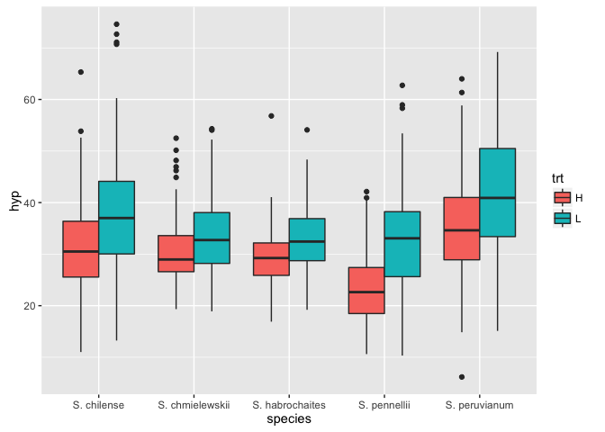

```r
ggplot(data=d,aes(y=hyp,x=species,fill=trt)) + geom_boxplot()
```

# fit model by treatment

```r
d$trt.l <- ifelse( d$trt=="L" , 1 , 0 )
levels(d$trt)
```

```
## [1] "H" "L"
```

```r
d.trt <- d[,c("hyp","trt.l")]

m.trt <- map2stan(
    alist(
        hyp ~ dnorm( mu , sigma ) ,
        mu <- a + bT*trt.l  ,
        a ~ dnorm( 33 , 10 ) ,
        bT ~ dnorm( 0 , 1 ) ,
        sigma ~ dunif( 0 , 10 )
) , data = d.trt )
```

[output not shown]

[output cut: 28 more lines]

[output not shown]

```
## Computing WAIC
```

```
## Constructing posterior predictions
```

[output not shown]

```r
precis(m.trt)
```

```
##        Mean StdDev lower 0.89 upper 0.89 n_eff Rhat
## a     31.42   0.42      30.75      32.06   265    1
## bT     3.84   0.52       2.94       4.55   316    1
## sigma  9.60   0.19       9.30       9.90   622    1
```

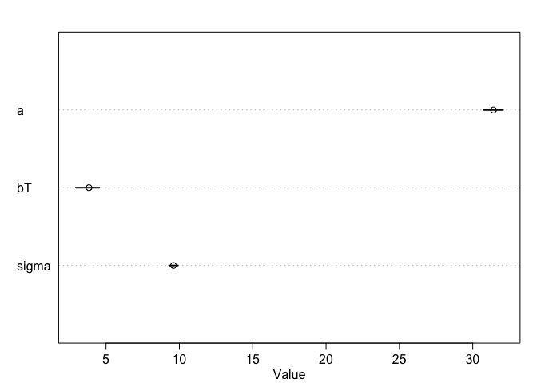

```r
plot(precis(m.trt))
```

# fit the model by species

```r
d.species <- d[,c("hyp","species")]
d.species$id <- 1:nrow(d.species)

### what do you want to be in each row ~ what do you want the rest of the collems to be, lengths gives us zeros or ones depending on which vaule it is.. need id/index so that it doesnt combine simlar values into a singel row.
d.species <- dcast(d.species, hyp + id ~ species, value.var="species", fun.aggregate = length)
colnames(d.species) <- sub(". ","_",fixed = TRUE, colnames(d.species))
head(d.species)
```

```
##     hyp  id S_chilense S_chmielewskii S_habrochaites S_pennellii
## 1  6.17 779          0              0              0           0
## 2 10.32 646          0              0              0           1
## 3 10.61 439          0              0              0           1
## 4 11.01 892          1              0              0           0
## 5 12.18 185          1              0              0           0
## 6 12.55  43          0              0              0           1
##   S_peruvianum
## 1            1
## 2            0
## 3            0
## 4            0
## 5            0
## 6            0
```

```r
d.species <- d.species[,c(-2,-4)]


m.species <- map2stan(
  alist(
    hyp ~ dnorm(mu,sigma),
    mu <- a + bChi * S_chilense + bHab * S_habrochaites + bPen * S_pennellii + bPer * S_peruvianum,
    a ~ dnorm(mu=33,sd=10),
    c(bChi, bHab, bPen, bPer) ~ dnorm(0,10),
    sigma ~ dcauchy(0,1)),
    data=d.species, chains=4, cores = 1)
```

[output not shown]

[output cut: 82 more lines]

[output not shown]

```
## Computing WAIC
```

```
## Constructing posterior predictions
```

[output not shown]

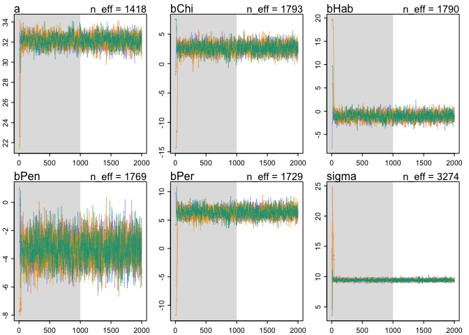

```r
plot(m.species)
```

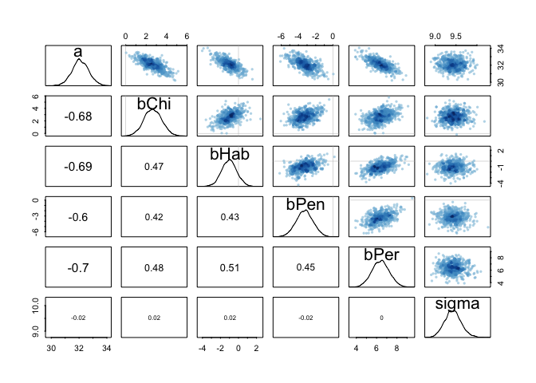

```r
par(mfrow=c(1,1),mfcol=c(1,1))
pairs(m.species)
```

```r
precis(m.species)
```

```
##        Mean StdDev lower 0.89 upper 0.89 n_eff Rhat
## a     32.10   0.60      31.11      33.02  1418    1
## bChi   2.66   0.87       1.28       4.04  1793    1
## bHab  -1.03   0.84      -2.37       0.29  1790    1
## bPen  -3.29   0.98      -4.78      -1.66  1769    1
## bPer   6.40   0.85       4.96       7.69  1729    1
## sigma  9.43   0.20       9.08       9.71  3274    1
```

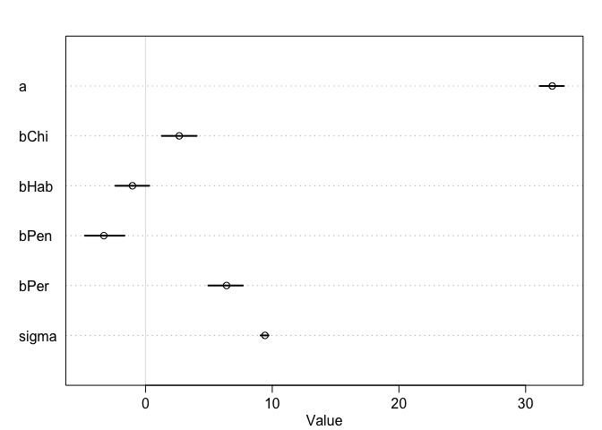

```r
plot(precis(m.species))
```

# species and treatment model

```r
trt_l <- d$trt.l
d.species_trt <- cbind(d.species,trt_l)
summary(d.species_trt)
```

```
##       hyp          S_chilense     S_habrochaites    S_pennellii
##  Min.   : 6.17   Min.   :0.0000   Min.   :0.0000   Min.   :0.000
##  1st Qu.:26.81   1st Qu.:0.0000   1st Qu.:0.0000   1st Qu.:0.000
##  Median :32.02   Median :0.0000   Median :0.0000   Median :0.000
##  Mean   :33.36   Mean   :0.2054   Mean   :0.2242   Mean   :0.131
##  3rd Qu.:38.56   3rd Qu.:0.0000   3rd Qu.:0.0000   3rd Qu.:0.000
##  Max.   :74.60   Max.   :1.0000   Max.   :1.0000   Max.   :1.000
##   S_peruvianum        trt_l
##  Min.   :0.0000   Min.   :0.0000
##  1st Qu.:0.0000   1st Qu.:0.0000
##  Median :0.0000   Median :1.0000
##  Mean   :0.2153   Mean   :0.5089
##  3rd Qu.:0.0000   3rd Qu.:1.0000
##  Max.   :1.0000   Max.   :1.0000
```

```r
m.species_trt <- map2stan(
  alist(
    hyp ~ dnorm(mu,sigma),
    mu <- a + bT*trt_l + bChi * S_chilense + bHab * S_habrochaites + bPen * S_pennellii + bPer * S_peruvianum,
    a ~ dnorm(mu=33,sd=10),
    c(bChi, bHab, bPen, bPer, bT) ~ dnorm(0,10),
    sigma ~ dcauchy(0,1)),
    data=d.species_trt, chains=4, cores = 1)
```

[output not shown]

[output cut: 82 more lines]

[output not shown]

```
## Computing WAIC
```

```
## Constructing posterior predictions
```

[output not shown]

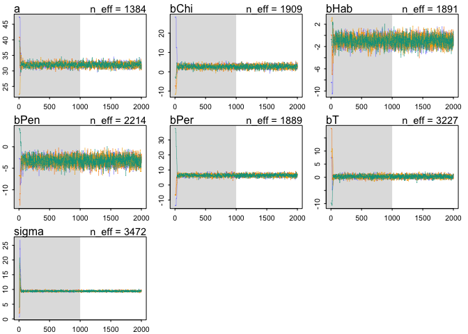

```r
plot(m.species_trt)
par(mfrow=c(1,1),mfcol=c(1,1))
```

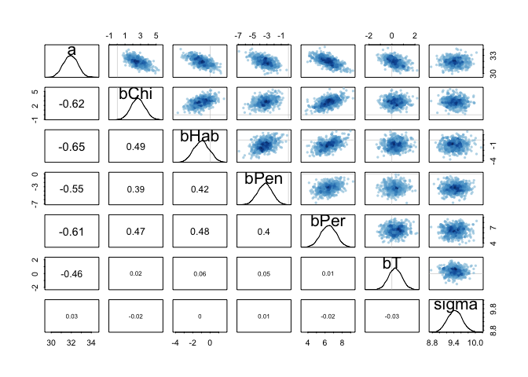

```r
pairs(m.species_trt)
```

```r
precis(m.species_trt)
```

```
##        Mean StdDev lower 0.89 upper 0.89 n_eff Rhat
## a     31.93   0.70      30.85      33.02  1384    1
## bChi   2.67   0.89       1.32       4.14  1909    1
## bHab  -0.99   0.88      -2.37       0.44  1891    1
## bPen  -3.28   1.01      -4.86      -1.66  2214    1
## bPer   6.41   0.89       4.95       7.75  1889    1
## bT     0.29   0.57      -0.65       1.16  3227    1
## sigma  9.43   0.20       9.12       9.75  3472    1
```

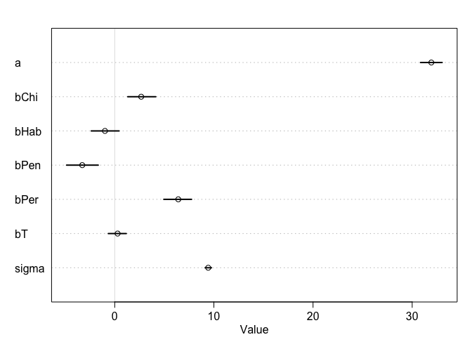

```r
plot(precis(m.species_trt))
```

Hab and Pen are lower then the mean while PER and CHi are higher. This is the same as before really need to look at interactions to get a better idea. BT really doesnt show any correlation with any species in particular but more with the S.CHM

# species by treatment model

```r
m.species_by_trt <- map2stan(
  alist(
    hyp ~ dnorm(mu,sigma),
    mu <- a + bChi * S_chilense *trt_l + bHab * S_habrochaites*trt_l  + bPen * S_pennellii*trt_l + bPer * S_peruvianum*trt_l,
    a ~ dnorm(mu=33,sd=10),
    c(bChi, bHab, bPen, bPer) ~ dnorm(0,10),
    sigma ~ dcauchy(0,1)),
    data=d.species_trt, chains=4, cores = 1)
```

[output not shown]

[output cut: 82 more lines]

[output not shown]

```
## Computing WAIC
```

```
## Constructing posterior predictions
```

[output not shown]

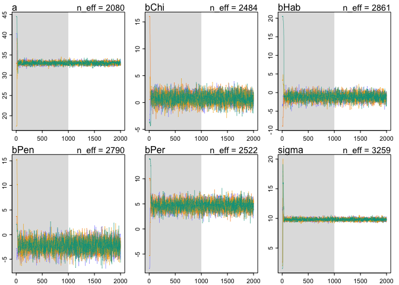

```r
plot(m.species_by_trt)
```

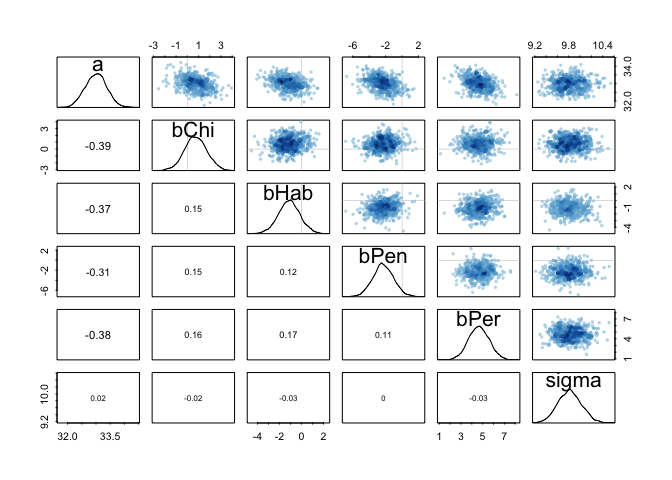

```r
par(mfrow=c(1,1),mfcol=c(1,1))
pairs(m.species_by_trt)
```

```r
precis(m.species_by_trt)
```

```
##        Mean StdDev lower 0.89 upper 0.89 n_eff Rhat
## a     33.00   0.38      32.41      33.60  2080    1
## bChi   0.75   0.98      -0.71       2.42  2484    1
## bHab  -1.12   0.97      -2.66       0.48  2861    1
## bPen  -2.30   1.28      -4.29      -0.22  2790    1
## bPer   4.65   0.94       3.11       6.10  2522    1
## sigma  9.82   0.21       9.50      10.16  3259    1
```

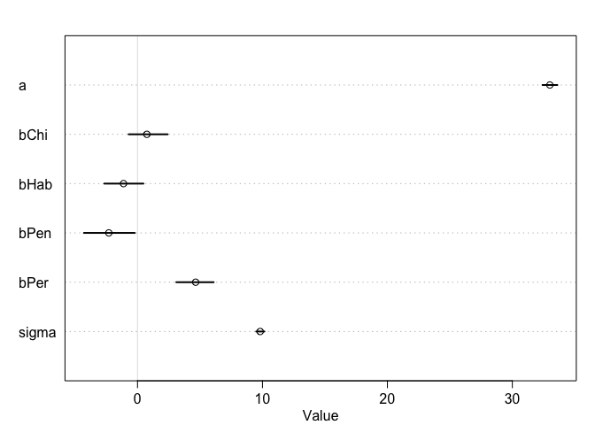

```r
plot(precis(m.species_by_trt))
```

HABs stan results are pretty noisey is this because alpha and hab have some correlation with each other…. or even the cause for the correlation…When trt is also interaction factor the species effect is not as large. PER seems to have the largest species and treatment effect.

# compare models on untransformed data

```r
compare(m.trt,m.species,m.species_trt,m.species_by_trt)
```

```
##                    WAIC pWAIC dWAIC weight    SE   dSE
## m.species        7389.9   6.1   0.0   0.77 57.28    NA
## m.species_trt    7392.3   7.5   2.5   0.23 57.53  1.03
## m.trt            7427.2   3.0  37.3   0.00 57.08 82.78
## m.species_by_trt 7470.6   4.8  80.8   0.00 57.95 19.97
```

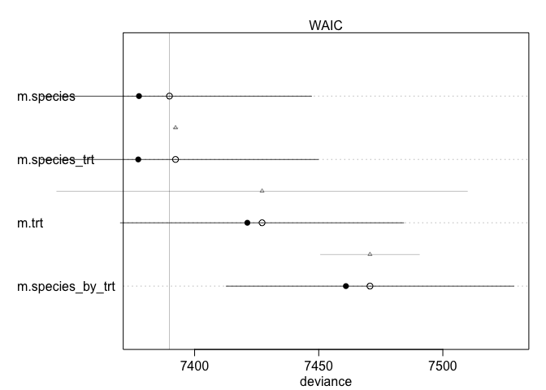

```r
plot(compare(m.trt,m.species,m.species_trt,m.species_by_trt))
```

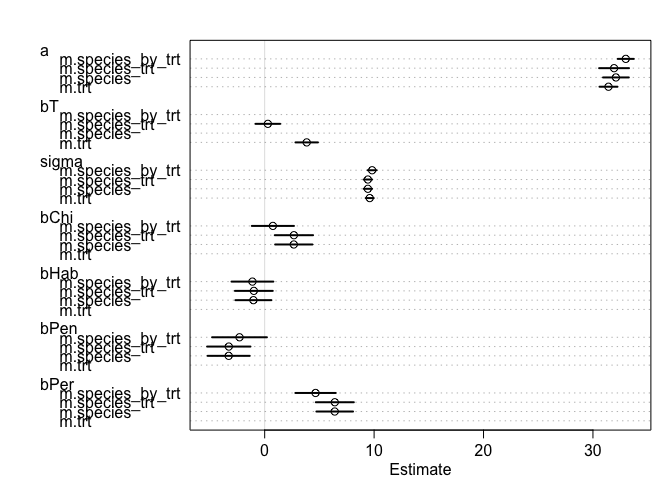

```r
plot(coeftab(m.trt,m.species,m.species_trt,m.species_by_trt))
```

```r
### transform data the does not have long tails....
### tells which are normal and which are not normal for hight and low for trt and species seperated
by(d$hyp,list(d$trt,d$species),shapiro.test)
```

```
## : H
## : S. chilense
##
##  Shapiro-Wilk normality test
##
## data:  dd[x, ]
## W = 0.97615, p-value = 0.06157
##
## --------------------------------------------------------
## : L
## : S. chilense
##
##  Shapiro-Wilk normality test
##
## data:  dd[x, ]
## W = 0.96132, p-value = 0.003754
##
## --------------------------------------------------------
## : H
## : S. chmielewskii
##
##  Shapiro-Wilk normality test
##
## data:  dd[x, ]
## W = 0.93713, p-value = 6.374e-05
##
## --------------------------------------------------------
## : L
## : S. chmielewskii
##
##  Shapiro-Wilk normality test
##
## data:  dd[x, ]
## W = 0.97217, p-value = 0.01553
##
## --------------------------------------------------------
## : H
## : S. habrochaites
##
##  Shapiro-Wilk normality test
```

[output cut: 33 more lines]

```
## : S. peruvianum
##
##  Shapiro-Wilk normality test
##
## data:  dd[x, ]
## W = 0.98393, p-value = 0.2357
##
## --------------------------------------------------------
## : L
## : S. peruvianum
##
##  Shapiro-Wilk normality test
##
## data:  dd[x, ]
## W = 0.99081, p-value = 0.6571
```

```r
## repeat for proposed transformation
by(sqrt(d$hyp),list(d$trt,d$species),shapiro.test)
```

```
## : H
## : S. chilense
##
##  Shapiro-Wilk normality test
##
## data:  dd[x, ]
## W = 0.98965, p-value = 0.6224
##
## --------------------------------------------------------
## : L
## : S. chilense
##
##  Shapiro-Wilk normality test
##
## data:  dd[x, ]
## W = 0.98696, p-value = 0.3991
##
## --------------------------------------------------------
## : H
## : S. chmielewskii
##
##  Shapiro-Wilk normality test
##
## data:  dd[x, ]
## W = 0.96342, p-value = 0.004341
##
## --------------------------------------------------------
## : L
## : S. chmielewskii
##
##  Shapiro-Wilk normality test
##
## data:  dd[x, ]
## W = 0.9881, p-value = 0.399
##
## --------------------------------------------------------
## : H
## : S. habrochaites
##
##  Shapiro-Wilk normality test
```

[output cut: 33 more lines]

```
## : S. peruvianum
##
##  Shapiro-Wilk normality test
##
## data:  dd[x, ]
## W = 0.97994, p-value = 0.1125
##
## --------------------------------------------------------
## : L
## : S. peruvianum
##
##  Shapiro-Wilk normality test
##
## data:  dd[x, ]
## W = 0.98796, p-value = 0.4209
```

```r
### sqrt  helps and makes the data more normal
by(log2(d$hyp),list(d$trt,d$species),shapiro.test)
```

```
## : H
## : S. chilense
##
##  Shapiro-Wilk normality test
##
## data:  dd[x, ]
## W = 0.97087, p-value = 0.02352
##
## --------------------------------------------------------
## : L
## : S. chilense
##
##  Shapiro-Wilk normality test
##
## data:  dd[x, ]
## W = 0.98253, p-value = 0.1827
##
## --------------------------------------------------------
## : H
## : S. chmielewskii
##
##  Shapiro-Wilk normality test
##
## data:  dd[x, ]
## W = 0.97867, p-value = 0.07747
##
## --------------------------------------------------------
## : L
## : S. chmielewskii
##
##  Shapiro-Wilk normality test
##
## data:  dd[x, ]
## W = 0.9949, p-value = 0.9493
##
## --------------------------------------------------------
## : H
## : S. habrochaites
##
##  Shapiro-Wilk normality test
```

[output cut: 33 more lines]

```
## : S. peruvianum
##
##  Shapiro-Wilk normality test
##
## data:  dd[x, ]
## W = 0.91602, p-value = 5.466e-06
##
## --------------------------------------------------------
## : L
## : S. peruvianum
##
##  Shapiro-Wilk normality test
##
## data:  dd[x, ]
## W = 0.96537, p-value = 0.005283
```

```r
data.species.trt.sqrt <- within(d.species_trt, hyp <- sqrt(hyp))

sqrt_hyp <- sqrt(d.species_trt$hyp)
d.species_trt_sqrt <- cbind(sqrt_hyp, d.species_trt[,2:6])
summary(d.species_trt_sqrt)
```

```
##     sqrt_hyp       S_chilense     S_habrochaites    S_pennellii
##  Min.   :2.484   Min.   :0.0000   Min.   :0.0000   Min.   :0.000
##  1st Qu.:5.178   1st Qu.:0.0000   1st Qu.:0.0000   1st Qu.:0.000
##  Median :5.659   Median :0.0000   Median :0.0000   Median :0.000
##  Mean   :5.713   Mean   :0.2054   Mean   :0.2242   Mean   :0.131
##  3rd Qu.:6.210   3rd Qu.:0.0000   3rd Qu.:0.0000   3rd Qu.:0.000
##  Max.   :8.637   Max.   :1.0000   Max.   :1.0000   Max.   :1.000
##   S_peruvianum        trt_l
##  Min.   :0.0000   Min.   :0.0000
##  1st Qu.:0.0000   1st Qu.:0.0000
##  Median :0.0000   Median :1.0000
##  Mean   :0.2153   Mean   :0.5089
##  3rd Qu.:0.0000   3rd Qu.:1.0000
##  Max.   :1.0000   Max.   :1.0000
```

# species and treatment transform model

```r
m.species_trt_sqrt <- map2stan(
  alist(
    sqrt_hyp ~ dnorm(mu,sigma),
    mu <- a + bT*trt_l + bChi * S_chilense + bHab * S_habrochaites + bPen * S_pennellii + bPer * S_peruvianum,
    a ~ dnorm(mu=6,sd=10),
    c(bChi, bHab, bPen, bPer, bT) ~ dnorm(0,10),
    sigma ~ dcauchy(0,1)),
    data=d.species_trt_sqrt, chains=4, cores = 1)
```

[output not shown]

[output cut: 82 more lines]

[output not shown]

```
## Computing WAIC
```

```
## Constructing posterior predictions
```

[output not shown]

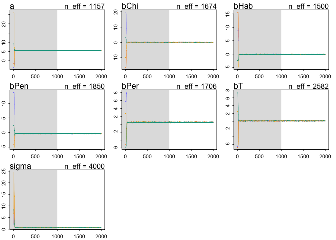

```r
plot(m.species_trt_sqrt)
par(mfrow=c(1,1),mfcol=c(1,1))
```

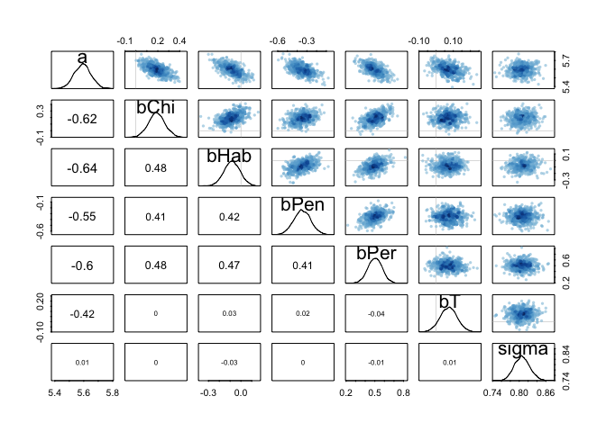

```r
pairs(m.species_trt_sqrt)
```

```r
precis(m.species_trt_sqrt)
```

```
##        Mean StdDev lower 0.89 upper 0.89 n_eff Rhat
## a      5.59   0.06       5.51       5.69  1157    1
## bChi   0.19   0.07       0.06       0.31  1674    1
## bHab  -0.08   0.07      -0.21       0.03  1500    1
## bPen  -0.35   0.09      -0.48      -0.21  1850    1
## bPer   0.50   0.07       0.39       0.63  1706    1
## bT     0.07   0.05       0.00       0.15  2582    1
## sigma  0.81   0.02       0.78       0.83  4000    1
```

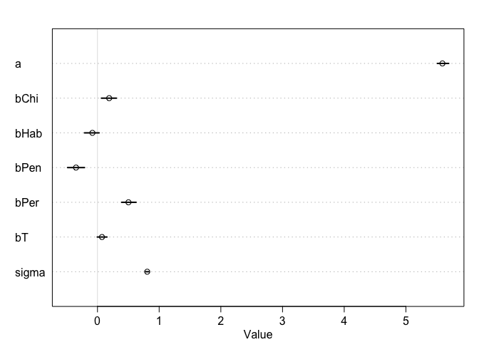

```r
plot(precis(m.species_trt_sqrt))
```

```r
compare(m.species_trt,m.species_trt_sqrt)
```

```
##                      WAIC pWAIC  dWAIC weight    SE   dSE
## m.species_trt_sqrt 2431.7   7.3    0.0      1 53.54    NA
## m.species_trt      7392.3   7.5 4960.6      0 57.53 17.57
```

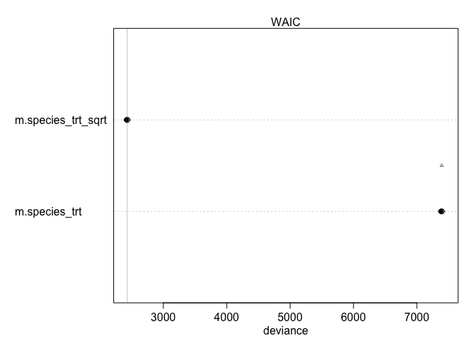

```r
plot(compare(m.species_trt,m.species_trt_sqrt))
```

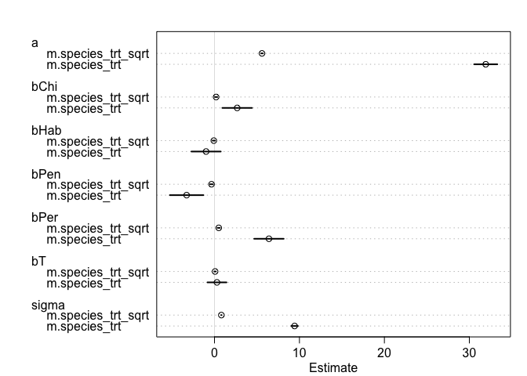

```r
plot(coeftab(m.species_trt,m.species_trt_sqrt))
```

It is unfair to compare using WAIC because WAIC uses the deviance and taking the sqrt changes the deviance between means… Also my stan is sooo small in smapling, not prop sampling the paramter space…!! Coetab shows posteior dist so there is more dev in the non-transformed model then in the transformed model. The means are also very differnet.